# NDVI-Based Crop Yield Prediction and Mapping Using Machine Learning

## Project Objective

The main objective of this project is to develop a Machine Learning Regression model for predicting crop yield using NDVI (Normalized Difference Vegetation Index) along with important agricultural and environmental factors.

The project aims to analyze how vegetation health, rainfall, soil moisture, temperature, irrigation, and crop characteristics affect crop yield.

## Problem Statement & Objectives

Problem Statement

Accurate crop-yield estimation is important for farmers, agricultural planners, and decision-makers. Traditional yield estimation methods can be time-consuming and may not effectively capture variations in crop health and environmental conditions.

This project uses NDVI and agricultural data to build a regression model that can predict crop yield more efficiently.

Objectives To analyze crop and environmental data. To study the relationship between NDVI and crop yield. To preprocess and prepare the dataset for Machine Learning. To train a regression model for crop-yield prediction. To evaluate the model using MAE, MSE, RMSE, and R² Score. To understand the important factors affecting crop yield.

## Why is this project important?

NDVI provides useful information about vegetation health and crop growth. Combining NDVI with rainfall, soil moisture, temperature, irrigation, and other agricultural factors can help estimate crop yield.

## Project Setup & Data Collection

The project is developed using **Python** and Machine Learning libraries such as Pandas, NumPy, Matplotlib, Seaborn, and Scikit-learn.

The dataset contains information related to **crop type, region, season, NDVI, rainfall, temperature, soil moisture, irrigation, soil properties, and crop yield**.

The target variable used for prediction is:

**`Yield_tons_per_hectare`**

```python
import pandas as pd
import numpy as np
import matplotlib.pyplot as plt
import seaborn as sns

df = pd.read_csv("NDVI_Crop_Yield_Mapping_Dataset.csv")

print("Dataset Shape:", df.shape)

df.head()
```

```
Dataset Shape: (1000, 20)
```

|  | Record_ID | Region | Crop_Type | Season | Irrigation_Type | NDVI | EVI | SAVI | LAI | Rainfall_mm | Temperature_C | Soil_Moisture | Fertilizer_kg_ha | Soil_pH | Organic_Carbon_pct | Canopy_Temperature_C | Growing_Days | Yield_tons_per_hectare | Healthy_Vegetation_Flag | Irrigation_Available |
| --- | --- | --- | --- | --- | --- | --- | --- | --- | --- | --- | --- | --- | --- | --- | --- | --- | --- | --- | --- | --- |
| 0 | NDVI-00001 | Madhya Pradesh | Sugarcane | Kharif | Tube Well | 0.915 | 0.861 | 0.827 | 5.39 | NaN | 25.70 | 0.620 | 74.7 | 7.23 | 1.25 | 23.89 | 298.0 | 15.98 | True | True |
| 1 | NDVI-00002 | Karnataka | Maize | Rabi | Tube Well | 0.736 | 0.643 | 0.717 | 4.55 | 452.7 | 27.58 | 0.403 | 60.3 | 6.55 | 0.67 | 27.21 | 130.0 | 8.13 | True | True |
| 2 | NDVI-00003 | Madhya Pradesh | Cotton | Kharif | Rainfed | 0.717 | NaN | 0.695 | 5.10 | 1120.2 | 29.91 | 0.620 | 78.2 | 7.95 | 0.96 | 28.24 | 159.0 | 9.82 | True | False |
| 3 | NDVI-00004 | Madhya Pradesh | Soybean | Rabi | NaN | 0.629 | 0.556 | 0.606 | 4.24 | 827.6 | 25.03 | 0.495 | 56.4 | 7.14 | 0.38 | 21.93 | 116.0 | 7.61 | False | False |
| 4 | NDVI-00005 | Punjab | Cotton | Kharif | Drip | 0.698 | 0.655 | 0.676 | 4.73 | 642.3 | 27.72 | 0.620 | 82.0 | 6.61 | 1.20 | 26.11 | NaN | 8.77 | True | True |

## Dataset Information

The dataset contains agricultural and environmental observations collected for different crops and regions.

It includes numerical, categorical, and boolean features that can be used for crop-yield prediction.

```python
print("Number of Rows:", df.shape[0])
print("Number of Columns:", df.shape[1])

df.info()
```

```
Number of Rows: 1000
Number of Columns: 20
<class 'pandas.core.frame.DataFrame'>
RangeIndex: 1000 entries, 0 to 999
Data columns (total 20 columns):
 #   Column                   Non-Null Count  Dtype
---  ------                   --------------  -----
 0   Record_ID                1000 non-null   object
 1   Region                   949 non-null    object
 2   Crop_Type                957 non-null    object
 3   Season                   954 non-null    object
 4   Irrigation_Type          951 non-null    object
 5   NDVI                     945 non-null    float64
 6   EVI                      952 non-null    float64
 7   SAVI                     942 non-null    float64
 8   LAI                      947 non-null    float64
 9   Rainfall_mm              958 non-null    float64
 10  Temperature_C            957 non-null    float64
 11  Soil_Moisture            961 non-null    float64
 12  Fertilizer_kg_ha         957 non-null    float64
 13  Soil_pH                  960 non-null    float64
 14  Organic_Carbon_pct       949 non-null    float64
 15  Canopy_Temperature_C     952 non-null    float64
 16  Growing_Days             947 non-null    float64
 17  Yield_tons_per_hectare   946 non-null    float64
 18  Healthy_Vegetation_Flag  1000 non-null   bool
 19  Irrigation_Available     1000 non-null   bool
dtypes: bool(2), float64(13), object(5)
memory usage: 142.7+ KB
```

```python
df.describe()
```

|  | NDVI | EVI | SAVI | LAI | Rainfall_mm | Temperature_C | Soil_Moisture | Fertilizer_kg_ha | Soil_pH | Organic_Carbon_pct | Canopy_Temperature_C | Growing_Days | Yield_tons_per_hectare |
| --- | --- | --- | --- | --- | --- | --- | --- | --- | --- | --- | --- | --- | --- |
| count | 945.000000 | 952.000000 | 942.000000 | 947.000000 | 958.000000 | 957.000000 | 961.000000 | 957.000000 | 960.000000 | 949.000000 | 952.000000 | 947.000000 | 946.000000 |
| mean | 0.739778 | 0.649000 | 0.702241 | 4.801394 | 711.334029 | 27.370021 | 0.504097 | 83.486938 | 6.985302 | 1.006344 | 24.385756 | 152.643083 | 9.435148 |
| std | 0.091749 | 0.066918 | 0.072294 | 0.600636 | 231.564814 | 3.857171 | 0.121310 | 21.176870 | 0.570907 | 0.255891 | 3.715383 | 60.632130 | 2.740007 |
| min | 0.062000 | 0.461000 | 0.518000 | 3.030000 | 120.000000 | 16.060000 | 0.136000 | 25.000000 | 5.200000 | 0.350000 | 14.990000 | 89.000000 | 0.800000 |
| 25% | 0.688000 | 0.599750 | 0.652000 | 4.410000 | 543.625000 | 24.470000 | 0.403000 | 69.900000 | 6.580000 | 0.820000 | 21.760000 | 117.000000 | 7.592500 |
| 50% | 0.740000 | 0.645500 | 0.699000 | 4.810000 | 689.800000 | 27.440000 | 0.526000 | 82.000000 | 6.980000 | 1.000000 | 24.115000 | 130.000000 | 9.230000 |
| 75% | 0.796000 | 0.698000 | 0.751000 | 5.210000 | 888.250000 | 30.200000 | 0.620000 | 95.100000 | 7.390000 | 1.180000 | 26.960000 | 158.000000 | 11.080000 |
| max | 0.920000 | 0.861000 | 0.891000 | 6.500000 | 1658.000000 | 39.530000 | 0.620000 | 228.100000 | 8.400000 | 1.860000 | 37.770000 | 330.000000 | 16.000000 |

## Missing Values

Missing-value analysis is performed to identify incomplete observations in the dataset before applying Machine Learning algorithms.

```python
missing_values = df.isnull().sum()

print(missing_values)
```

```
Record_ID                   0
Region                     51
Crop_Type                  43
Season                     46
Irrigation_Type            49
NDVI                       55
EVI                        48
SAVI                       58
LAI                        53
Rainfall_mm                42
Temperature_C              43
Soil_Moisture              39
Fertilizer_kg_ha           43
Soil_pH                    40
Organic_Carbon_pct         51
Canopy_Temperature_C       48
Growing_Days               53
Yield_tons_per_hectare     54
Healthy_Vegetation_Flag     0
Irrigation_Available        0
dtype: int64
```

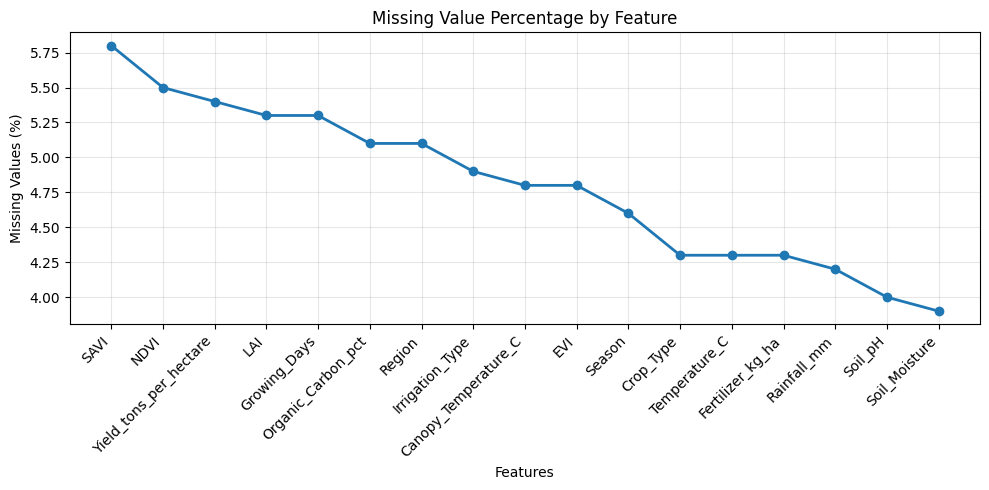

```python
plt.figure(figsize=(10, 5))

missing_percent = (
    df.isnull().mean() * 100
).sort_values(ascending=False)

missing_percent = missing_percent[missing_percent > 0]

plt.plot(
    missing_percent.index,
    missing_percent.values,
    marker="o",
    linewidth=2
)

plt.title("Missing Value Percentage by Feature")
plt.xlabel("Features")
plt.ylabel("Missing Values (%)")

plt.xticks(rotation=45, ha="right")
plt.grid(alpha=0.3)
plt.tight_layout()

plt.show()
```

## Exploratory Data Analysis (EDA)

Exploratory Data Analysis is performed to understand the distribution of crop yield and the relationship between NDVI and other agricultural factors.

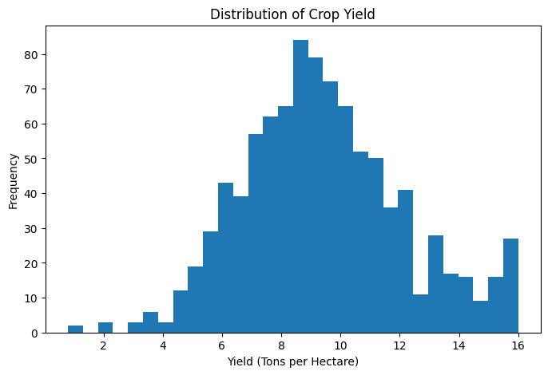

```python
plt.figure(figsize=(8,5))

plt.hist(
    df["Yield_tons_per_hectare"].dropna(),
    bins=30
)

plt.title("Distribution of Crop Yield")
plt.xlabel("Yield (Tons per Hectare)")
plt.ylabel("Frequency")

plt.show()
```

## NDVI vs Crop Yield

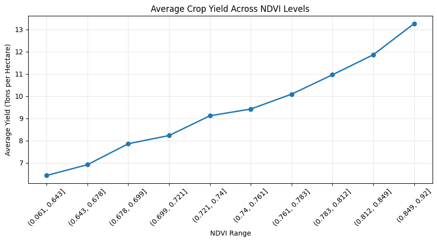

```python
plt.figure(figsize=(9, 5))

ndvi_groups = pd.qcut(
    df["NDVI"],
    q=10,
    duplicates="drop"
)

ndvi_yield = df.groupby(
    ndvi_groups,
    observed=True
)["Yield_tons_per_hectare"].mean()

plt.plot(
    ndvi_yield.index.astype(str),
    ndvi_yield.values,
    marker="o",
    linewidth=2
)

plt.title("Average Crop Yield Across NDVI Levels")
plt.xlabel("NDVI Range")
plt.ylabel("Average Yield (Tons per Hectare)")

plt.xticks(rotation=45)
plt.grid(alpha=0.3)
plt.tight_layout()

plt.show()
```

## Rainfall vs Crop Yield

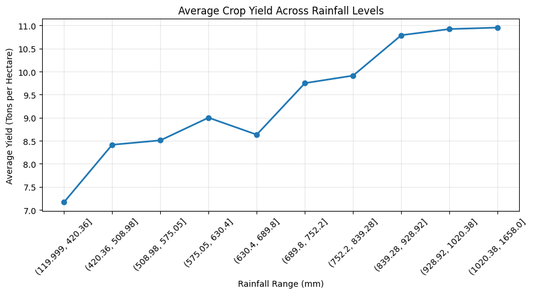

```python
plt.figure(figsize=(9, 5))

rainfall_groups = pd.qcut(
    df["Rainfall_mm"],
    q=10,
    duplicates="drop"
)

rainfall_yield = df.groupby(
    rainfall_groups,
    observed=True
)["Yield_tons_per_hectare"].mean()

plt.plot(
    rainfall_yield.index.astype(str),
    rainfall_yield.values,
    marker="o",
    linewidth=2
)

plt.title("Average Crop Yield Across Rainfall Levels")
plt.xlabel("Rainfall Range (mm)")
plt.ylabel("Average Yield (Tons per Hectare)")

plt.xticks(rotation=45)
plt.grid(alpha=0.3)
plt.tight_layout()

plt.show()
```

## Crop-wise Yield

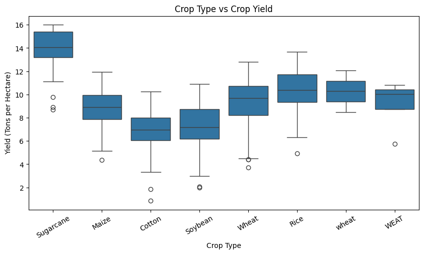

```python
plt.figure(figsize=(10,5))

sns.boxplot(
    data=df,
    x="Crop_Type",
    y="Yield_tons_per_hectare"
)

plt.title("Crop Type vs Crop Yield")
plt.xlabel("Crop Type")
plt.ylabel("Yield (Tons per Hectare)")

plt.xticks(rotation=30)
plt.show()
```

## Correlation Heatmap

The correlation heatmap is used to understand the relationships between numerical variables.

It helps identify features that may have a strong relationship with crop yield.

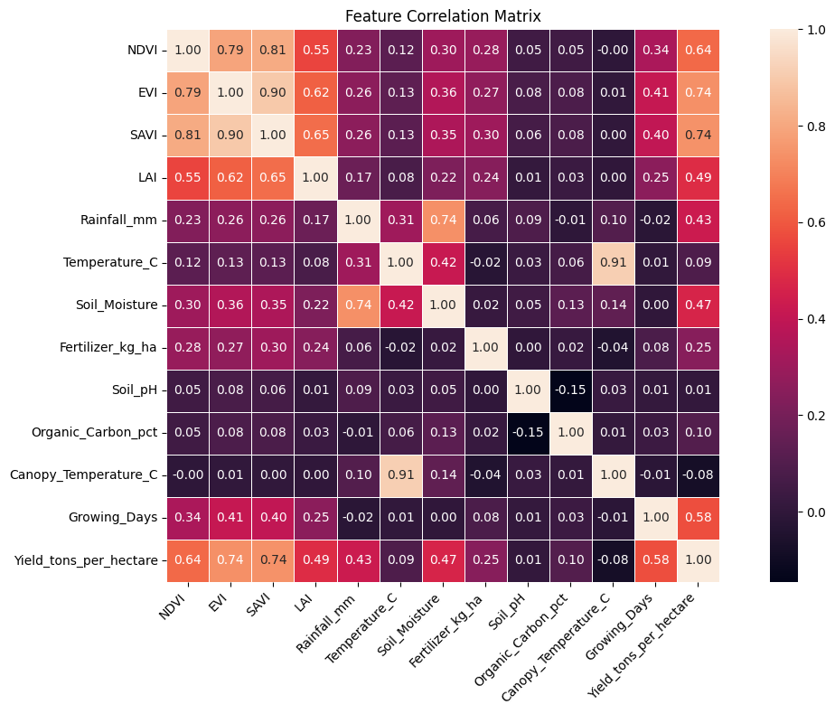

```python
plt.figure(figsize=(12, 8))

numeric_df = df.select_dtypes(include=np.number)

corr_matrix = numeric_df.corr()

sns.heatmap(
    corr_matrix,
    annot=True,
    fmt=".2f",
    linewidths=0.5,
    square=True
)

plt.title("Feature Correlation Matrix")
plt.xticks(rotation=45, ha="right")
plt.yticks(rotation=0)

plt.tight_layout()
plt.show()
```

## 6. Data Preprocessing

The dataset is prepared for Machine Learning by handling missing values, separating features and target variables, encoding categorical variables, and scaling numerical features.

```python
from sklearn.model_selection import train_test_split
from sklearn.compose import ColumnTransformer
from sklearn.pipeline import Pipeline
from sklearn.impute import SimpleImputer
from sklearn.preprocessing import OneHotEncoder, StandardScaler

X = df.drop(
    columns=["Record_ID", "Yield_tons_per_hectare"]
)

y = df["Yield_tons_per_hectare"]

print("Features Shape:", X.shape)
print("Target Shape:", y.shape)
```

```
Features Shape: (1000, 18)
Target Shape: (1000,)
```

```python
categorical_cols = X.select_dtypes(
    include=["object"]
).columns

numerical_cols = X.select_dtypes(
    include=[np.number]
).columns

print("Categorical Features:")
print(list(categorical_cols))

print("\nNumerical Features:")
print(list(numerical_cols))
```

```
Categorical Features:
['Region', 'Crop_Type', 'Season', 'Irrigation_Type']

Numerical Features:
['NDVI', 'EVI', 'SAVI', 'LAI', 'Rainfall_mm', 'Temperature_C', 'Soil_Moisture', 'Fertilizer_kg_ha', 'Soil_pH', 'Organic_Carbon_pct', 'Canopy_Temperature_C', 'Growing_Days']
```

## Feature Engineering

```python
# Feature Engineering

df["NDVI_Rainfall_Interaction"] = (
    df["NDVI"] * df["Rainfall_mm"]
)

df["Temperature_SoilMoisture_Interaction"] = (
    df["Temperature_C"] * df["Soil_Moisture"]
)

df["Moisture_Rainfall_Ratio"] = (
    df["Soil_Moisture"] / (df["Rainfall_mm"] + 1)
)

df["Vegetation_Index_Average"] = (
    df[["NDVI", "EVI", "SAVI"]].mean(axis=1)
)

df.head()
```

|  | Record_ID | Region | Crop_Type | Season | Irrigation_Type | NDVI | EVI | SAVI | LAI | Rainfall_mm | ... | Organic_Carbon_pct | Canopy_Temperature_C | Growing_Days | Yield_tons_per_hectare | Healthy_Vegetation_Flag | Irrigation_Available | NDVI_Rainfall_Interaction | Temperature_SoilMoisture_Interaction | Moisture_Rainfall_Ratio | Vegetation_Index_Average |
| --- | --- | --- | --- | --- | --- | --- | --- | --- | --- | --- | --- | --- | --- | --- | --- | --- | --- | --- | --- | --- | --- |
| 0 | NDVI-00001 | Madhya Pradesh | Sugarcane | Kharif | Tube Well | 0.915 | 0.861 | 0.827 | 5.39 | NaN | ... | 1.25 | 23.89 | 298.0 | 15.98 | True | True | NaN | 15.93400 | NaN | 0.867667 |
| 1 | NDVI-00002 | Karnataka | Maize | Rabi | Tube Well | 0.736 | 0.643 | 0.717 | 4.55 | 452.7 | ... | 0.67 | 27.21 | 130.0 | 8.13 | True | True | 333.1872 | 11.11474 | 0.000888 | 0.698667 |
| 2 | NDVI-00003 | Madhya Pradesh | Cotton | Kharif | Rainfed | 0.717 | NaN | 0.695 | 5.10 | 1120.2 | ... | 0.96 | 28.24 | 159.0 | 9.82 | True | False | 803.1834 | 18.54420 | 0.000553 | 0.706000 |
| 3 | NDVI-00004 | Madhya Pradesh | Soybean | Rabi | NaN | 0.629 | 0.556 | 0.606 | 4.24 | 827.6 | ... | 0.38 | 21.93 | 116.0 | 7.61 | False | False | 520.5604 | 12.38985 | 0.000597 | 0.597000 |
| 4 | NDVI-00005 | Punjab | Cotton | Kharif | Drip | 0.698 | 0.655 | 0.676 | 4.73 | 642.3 | ... | 1.20 | 26.11 | NaN | 8.77 | True | True | 448.3254 | 17.18640 | 0.000964 | 0.676333 |

5 rows × 24 columns

## Train-Test Split

```python
valid_rows = y.notna()

X = X[valid_rows]
y = y[valid_rows]

X_train, X_test, y_train, y_test = train_test_split(
    X,
    y,
    test_size=0.20,
    random_state=42
)

print("Training Data:", X_train.shape)
print("Testing Data:", X_test.shape)
```

```
Training Data: (756, 18)
Testing Data: (190, 18)
```

## Feature Preprocessing

```python
preprocessor = ColumnTransformer(
    transformers=[
        (
            "num",
            Pipeline([
                ("imputer", SimpleImputer(strategy="median")),
                ("scaler", StandardScaler())
            ]),
            numerical_cols
        ),
        (
            "cat",
            Pipeline([
                ("imputer", SimpleImputer(strategy="most_frequent")),
                ("encoder", OneHotEncoder(handle_unknown="ignore"))
            ]),
            categorical_cols
        )
    ]
)
```

## Model Building

A **Random Forest Regression** model is used for crop-yield prediction.

Random Forest can capture non-linear relationships between NDVI, environmental conditions, soil properties, irrigation, and crop characteristics.

```python
from sklearn.ensemble import RandomForestRegressor

model = Pipeline([
    ("preprocessor", preprocessor),
    (
        "regressor",
        RandomForestRegressor(
            n_estimators=250,
            random_state=42,
            n_jobs=-1
        )
    )
])

model.fit(X_train, y_train)

print("Model Training Completed Successfully!")
```

```
Model Training Completed Successfully!
```

## Prediction & Evaluation

After training the model, predictions are generated using the testing dataset.

```python
y_pred = model.predict(X_test)

print("Predictions Generated Successfully!")
print(y_pred[:10])
```

```
Predictions Generated Successfully!
[10.31376  5.87316  8.95632 10.11208  8.64172  7.54412  9.49112 11.5718
 10.54528  7.32888]
```

### Model Evaluation

```python
from sklearn.metrics import (
    mean_absolute_error,
    mean_squared_error,
    r2_score
)

mae = mean_absolute_error(y_test, y_pred)

mse = mean_squared_error(y_test, y_pred)

rmse = np.sqrt(mse)

r2 = r2_score(y_test, y_pred)

print("Mean Absolute Error (MAE):", mae)
print("Mean Squared Error (MSE):", mse)
print("Root Mean Squared Error (RMSE):", rmse)
print("R² Score:", r2)
```

```
Mean Absolute Error (MAE): 0.6663433684210536
Mean Squared Error (MSE): 0.8824872031073699
Root Mean Squared Error (RMSE): 0.93940790027941
R² Score: 0.8781500749493669
```

## Actual vs Predicted Crop Yield

The actual and predicted crop-yield values are compared to visually evaluate the performance of the regression model.

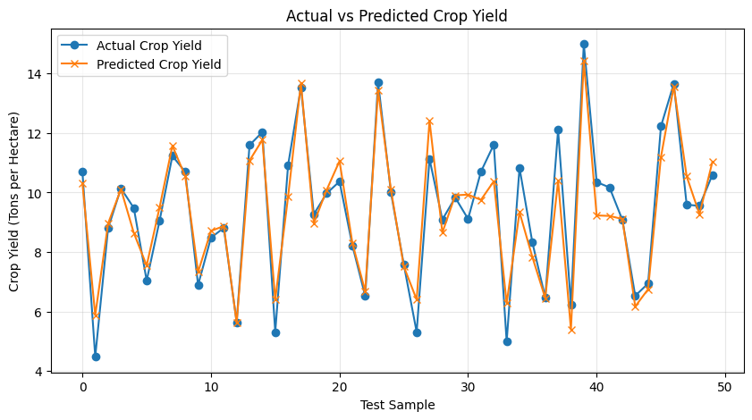

```python
plt.figure(figsize=(10, 5))

plt.plot(
    y_test.reset_index(drop=True).head(50),
    label="Actual Crop Yield",
    marker="o"
)

plt.plot(
    pd.Series(y_pred).head(50),
    label="Predicted Crop Yield",
    marker="x"
)

plt.xlabel("Test Sample")
plt.ylabel("Crop Yield (Tons per Hectare)")
plt.title("Actual vs Predicted Crop Yield")
plt.legend()
plt.grid(alpha=0.3)

plt.show()
```

## Predict New Crop Yield

The trained model can be used to predict crop yield for new agricultural observations by providing NDVI and other relevant environmental and crop-related features.

```
Predicted Crop Yield: 8.93 Tons per Hectare
```

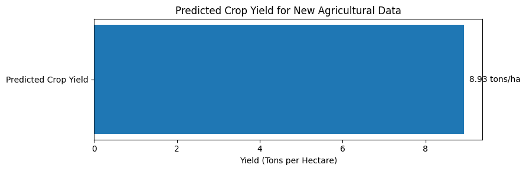

```python
new_data = pd.DataFrame({
    "Region": ["Maharashtra"],
    "Crop_Type": ["Wheat"],
    "Season": ["Rabi"],
    "Irrigation_Type": ["Canal"],
    "NDVI": [0.72],
    "EVI": [0.63],
    "SAVI": [0.68],
    "LAI": [4.5],
    "Rainfall_mm": [650],
    "Temperature_C": [24],
    "Soil_Moisture": [0.38],
    "Fertilizer_kg_ha": [100],
    "Soil_pH": [6.8],
    "Organic_Carbon_pct": [1.1],
    "Canopy_Temperature_C": [23],
    "Growing_Days": [120],
    "Healthy_Vegetation_Flag": [True],
    "Irrigation_Available": [True]
})

# Predict crop yield
prediction = model.predict(new_data)
predicted_yield = prediction[0]

print(f"Predicted Crop Yield: {predicted_yield:.2f} Tons per Hectare")

# Prediction graph
plt.figure(figsize=(9, 3))

plt.barh(
    ["Predicted Crop Yield"],
    [predicted_yield],
    height=0.45
)

plt.xlabel("Yield (Tons per Hectare)")
plt.title("Predicted Crop Yield for New Agricultural Data")

plt.text(
    predicted_yield,
    0,
    f"  {predicted_yield:.2f} tons/ha",
    va="center"
)

plt.tight_layout()
plt.show()
```

## Project Summary

This project develops a Machine Learning Regression model to predict crop yield using NDVI and agricultural and environmental factors. The project includes EDA, data preprocessing, feature engineering, model building, and evaluation using a Random Forest Regression model.

## Conclusion

The project demonstrates the use of **NDVI and Machine Learning for crop-yield prediction**.

NDVI combined with agricultural and environmental features provides useful information for estimating crop productivity. The Random Forest Regression model provides a data-driven approach for predicting crop yield and can support agricultural monitoring and planning.

## Future Scope

The project can be further improved by:

- Using real-time satellite imagery and NDVI data.
- Integrating GIS-based crop mapping.
- Using higher-resolution satellite images.
- Applying advanced Machine Learning and Deep Learning models.
- Developing a web-based crop-yield prediction system.
- Using real-world agricultural datasets for improved accuracy.